# Analyse des données de morbidité et recours aux soins

DIALLO Mamadou Moussa - DIOP Papa Boubacar

2026-03-17

Analyse :

knitr::opts_chunk$set(…) : configure les options pour tous les chunks du document RMarkdown :

echo = TRUE → affiche le code dans le rendu final.

warning = FALSE, message = FALSE → supprime les avertissements et messages dans le rendu.

fig.width = 10, fig.height = 6 → définit la taille par défaut des graphiques.

rm(list=ls()) : vide l’environnement, c’est-à-dire supprime toutes les variables existantes pour commencer avec un espace propre.

Interprétation :

Ce bloc est le setup initial du TP3, garantissant que le document RMarkdown affiche le code proprement, que les graphiques ont une taille standard et que l’environnement n’est pas pollué par des variables précédentes. # Chargement des packages

```r
library(haven)
library(dplyr)
library(ggplot2)
library(naniar)
library(rstatix)
library(scales)
library(gtsummary)
library(patchwork)
library(gt)
library(knitr)
```

# Importation des données

```r
# Chargement des données de morbidité
data <- read_stata("../data/raw/sect4a_harvestw4.dta")

# Chargement et préparation des données sociodémographiques
data_to_join <- read_stata("../data/raw/sect1_harvestw4.dta")
data_to_join <- data_to_join %>% select(hhid, indiv, s1q2, s1q4)

# Jointure
data <- inner_join(data, data_to_join, by = c("hhid", "indiv"))
```

Analyse :

read_stata(“../data/raw/sect4a_harvestw4.dta”) : importe les données de morbidité (secteur 4a) depuis un fichier Stata.

read_stata(“../data/raw/sect1_harvestw4.dta”) : importe les données sociodémographiques (secteur 1).

select(hhid, indiv, s1q2, s1q4) : ne garde que les colonnes essentielles :

hhid → identifiant du ménage

indiv → identifiant de l’individu

s1q2 → sexe

s1q4 → âge

inner_join(data, data_to_join, by = c(“hhid”, “indiv”)) : combine les deux jeux de données pour que chaque enregistrement de morbidité ait les informations sociodémographiques correspondantes.

Interprétation :

Après cette étape, data contient toutes les informations nécessaires pour analyser la morbidité en lien avec l’âge et le sexe.

Les individus qui n’apparaissent pas dans les deux fichiers sont exclus, ce qui assure une correspondance exacte entre morbidité et caractéristiques sociodémographiques. # Taux de morbidité global

```r
taux_global <- data %>%
  summarise(
    taux_de_morbidite = mean(s4aq3 == 1, na.rm = TRUE),
    .groups = "drop"
  )

taux_global %>%
  mutate(taux_de_morbidite = percent(taux_de_morbidite, accuracy = 0.1)) %>%
  kable(col.names = "Taux de morbidité global", caption = "Taux de morbidité dans la population")
```

Taux de morbidité dans la population

| Taux de morbidité global |
| --- |
| 9.3% |

Analyse :

summarise(taux_de_morbidite = mean(s4aq3 == 1, na.rm = TRUE)) :

Calcule le taux de morbidité global dans l’échantillon.

s4aq3 == 1 → considère qu’un individu est malade si la variable vaut 1.

na.rm = TRUE → ignore les valeurs manquantes.

mutate(… percent(…)) : convertit le taux en pourcentage avec une décimale pour plus de lisibilité.

kable(…) : crée un tableau simple affichant le taux de morbidité global avec un titre clair.

Interprétation :

Ce code donne le pourcentage d’individus malades dans l’ensemble de la population étudiée.

Le tableau final permet de présenter le taux de morbidité global de façon lisible et prête à être incluse dans un rapport ou un TP. # Préparation des données pour l’analyse

```r
data_morb <- data %>%
  mutate(
    malade = ifelse(s4aq3 == 1, 1, 0),
    sexe = as_factor(s1q2),
    age = s1q4,
    groupe_age = cut(
      age,
      breaks = c(0, 5, 15, 25, 45, 65, Inf),
      right = FALSE,
      labels = c("0-4 ans", "5-14 ans", "15-24 ans", "25-44 ans", "45-64 ans", "65 ans et plus")
    )
  ) %>%
  filter(!is.na(malade), !is.na(sexe), !is.na(groupe_age))
```

Analyse :

mutate(…) : crée et prépare des variables pour l’analyse :

malade = ifelse(s4aq3 == 1, 1, 0) → codage binaire : 1 = malade, 0 = non malade.

sexe = as_factor(s1q2) → convertit le sexe en facteur pour analyses et graphiques.

age = s1q4 → copie la variable âge.

groupe_age = cut(…) → regroupe les âges en tranches : 0–4, 5–14, 15–24, 25–44, 45–64, ≥65 ans.

filter(!is.na(…)) : supprime les individus pour lesquels l’une de ces variables est manquante.

Interprétation :

Le tableau data_morb est maintenant prêt pour l’analyse de la morbidité par sexe et par tranche d’âge.

Chaque ligne contient : la variable binaire malade, le sexe, l’âge et le groupe_age.

Cela permet de calculer facilement des taux de morbidité globaux et stratifiés, et de produire des graphiques comparatifs. # Analyse par sexe

## Taux de morbidité par sexe avec intervalle de confiance

```r
tab_sexe <- data_morb %>%
  group_by(sexe) %>%
  summarise(
    effectif = n(),
    cas = sum(malade, na.rm = TRUE),
    proportion = cas / effectif,
    IC_low = prop.test(cas, effectif)$conf.int[1],
    IC_up = prop.test(cas, effectif)$conf.int[2],
    .groups = "drop"
  ) %>%
  mutate(
    proportion_pct = percent(proportion, accuracy = 0.1),
    IC = paste0("[", percent(IC_low, accuracy = 0.1), " ; ", percent(IC_up, accuracy = 0.1), "]")
  )

# Affichage du tableau
tab_sexe %>%
  select(sexe, effectif, cas, proportion_pct, IC) %>%
  kable(
    col.names = c("Sexe", "Effectif", "Cas", "Proportion", "IC à 95%"),
    caption = "Taux de morbidité par sexe"
  )
```

Taux de morbidité par sexe

| Sexe | Effectif | Cas | Proportion | IC à 95% |
| --- | --- | --- | --- | --- |
| 1. MALE | 11134 | 930 | 8.4% | [7.8% ; 8.9%] |
| 2. FEMALE | 11037 | 1135 | 10.3% | [9.7% ; 10.9%] |

Le tableau tab_sexe montre le taux de morbidité pour chaque sexe avec le nombre de cas et l’intervalle de confiance.

Permet de comparer visuellement et statistiquement la morbidité entre hommes et femmes.

Les IC donnent une idée de la précision des estimations pour chaque groupe ## Visualisation

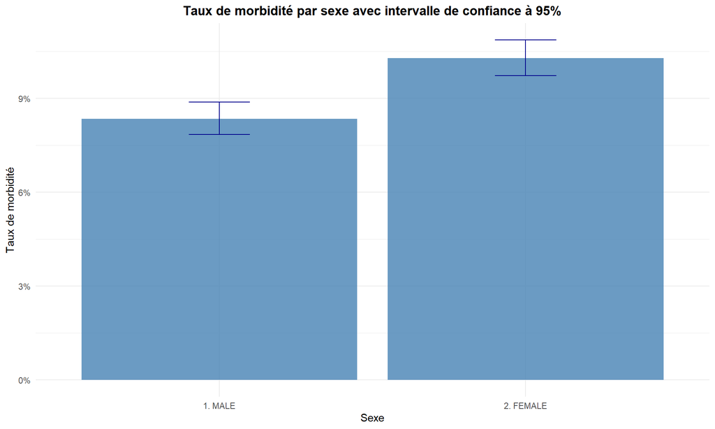

```r
ggplot(tab_sexe, aes(x = sexe, y = proportion)) +
  geom_col(fill = "steelblue", alpha = 0.8) +
  geom_errorbar(aes(ymin = IC_low, ymax = IC_up), width = 0.2, color = "darkblue") +
  scale_y_continuous(labels = percent_format(accuracy = 1)) +
  labs(
    x = "Sexe",
    y = "Taux de morbidité",
    title = "Taux de morbidité par sexe avec intervalle de confiance à 95%"
  ) +
  theme_minimal() +
  theme(plot.title = element_text(face = "bold", hjust = 0.5))
```

Analyse :

ggplot(tab_sexe, aes(x = sexe, y = proportion)) : crée un graphique avec le sexe sur l’axe x et le taux de morbidité sur l’axe y.

geom_col(fill = “steelblue”, alpha = 0.8) : dessine des barres verticales représentant le taux de morbidité pour chaque sexe.

geom_errorbar(aes(ymin = IC_low, ymax = IC_up), …) : ajoute les intervalles de confiance à 95% sous forme de barres d’erreur.

scale_y_continuous(labels = percent_format(accuracy = 1)) : affiche l’axe y en pourcentage.

labs(…) : titre et noms des axes.

theme_minimal() et theme(…) : style épuré et titre centré en gras.

Interprétation :

Le graphique montre visuellement le taux de morbidité pour chaque sexe avec sa précision statistique.

Les barres d’erreur indiquent la variabilité et la confiance dans les proportions estimées.

Permet de comparer directement hommes et femmes et de voir si les différences sont importantes ou non. # Analyse par groupe d’âge

## Taux de morbidité par groupe d’âge

```r
tab_age <- data_morb %>%
  group_by(groupe_age) %>%
  summarise(
    effectif = n(),
    cas = sum(malade, na.rm = TRUE),
    proportion = cas / effectif,
    IC_low = prop.test(cas, effectif)$conf.int[1],
    IC_up = prop.test(cas, effectif)$conf.int[2],
    .groups = "drop"
  ) %>%
  mutate(
    proportion_pct = percent(proportion, accuracy = 0.1),
    IC = paste0("[", percent(IC_low, accuracy = 0.1), " ; ", percent(IC_up, accuracy = 0.1), "]")
  )

# Affichage du tableau
tab_age %>%
  select(groupe_age, effectif, cas, proportion_pct, IC) %>%
  kable(
    col.names = c("Groupe d'âge", "Effectif", "Cas", "Proportion", "IC à 95%"),
    caption = "Taux de morbidité par groupe d'âge"
  )
```

Taux de morbidité par groupe d’âge

| Groupe d’âge | Effectif | Cas | Proportion | IC à 95% |
| --- | --- | --- | --- | --- |
| 0-4 ans | 2561 | 295 | 11.5% | [10.3% ; 12.8%] |
| 5-14 ans | 7119 | 436 | 6.1% | [5.6% ; 6.7%] |
| 15-24 ans | 4296 | 296 | 6.9% | [6.2% ; 7.7%] |
| 25-44 ans | 4809 | 451 | 9.4% | [8.6% ; 10.2%] |
| 45-64 ans | 2532 | 374 | 14.8% | [13.4% ; 16.2%] |
| 65 ans et plus | 854 | 213 | 24.9% | [22.1% ; 28.0%] |

Analyse :

group_by(groupe_age) : regroupe les individus par tranche d’âge.

summarise(…) : pour chaque groupe d’âge, calcule :

effectif → nombre total d’individus

cas → nombre d’individus malades (malade = 1)

proportion → taux de morbidité (cas / effectif)

IC_low et IC_up → bornes inférieure et supérieure de l’intervalle de confiance à 95% avec prop.test().

mutate(…) : formate les résultats pour affichage :

proportion_pct → proportion en pourcentage

IC → intervalle de confiance en pourcentage sous forme [min ; max].

kable(…) : crée un tableau clair et lisible avec colonnes : Groupe d’âge, Effectif, Cas, Proportion, IC à 95%.

Interprétation :

Le tableau tab_age permet de visualiser le taux de morbidité pour chaque tranche d’âge.

Les IC montrent la précision de l’estimation pour chaque groupe.

Cela permet de comparer la morbidité selon l’âge et d’identifier les groupes les plus à risque. ## Visualisation

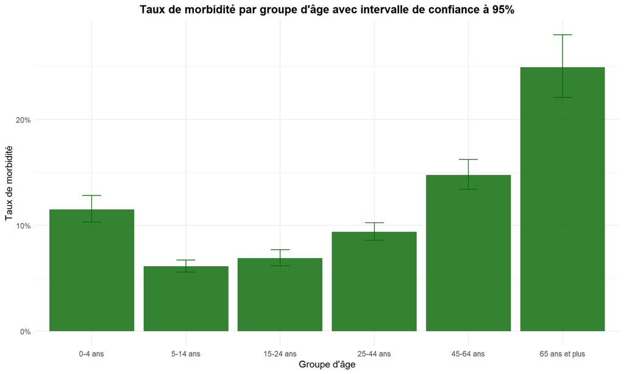

```r
ggplot(tab_age, aes(x = groupe_age, y = proportion)) +
  geom_col(fill = "darkgreen", alpha = 0.8) +
  geom_errorbar(aes(ymin = IC_low, ymax = IC_up), width = 0.2, color = "darkgreen") +
  scale_y_continuous(labels = percent_format(accuracy = 1)) +
  labs(
    x = "Groupe d'âge",
    y = "Taux de morbidité",
    title = "Taux de morbidité par groupe d'âge avec intervalle de confiance à 95%"
  ) +
  theme_minimal() +
  theme(plot.title = element_text(face = "bold", hjust = 0.5))
```

Analyse :

ggplot(tab_age, aes(x = groupe_age, y = proportion)) : crée un graphique avec les tranches d’âge sur l’axe x et le taux de morbidité sur l’axe y.

geom_col(fill = “darkgreen”, alpha = 0.8) : dessine des barres verticales pour chaque tranche d’âge.

geom_errorbar(aes(ymin = IC_low, ymax = IC_up), …) : ajoute les intervalles de confiance à 95% pour chaque barre.

scale_y_continuous(labels = percent_format(accuracy = 1)) : affiche l’axe y en pourcentage.

labs(…) : définit le titre et les noms des axes.

theme_minimal() et theme(…) : style épuré et titre centré en gras.

Interprétation :

Le graphique permet de visualiser le taux de morbidité selon les tranches d’âge.

Les barres d’erreur montrent la variabilité et la précision des proportions estimées pour chaque groupe.

Cela permet d’identifier les groupes d’âge les plus à risque et de comparer la morbidité entre eux facilement. # Distribution des types de maladies

```r
data_maladie <- data %>%
  mutate(type_maladie = as_factor(s4aq3b_1)) %>%
  filter(!is.na(type_maladie))

top_maladies <- data_maladie %>%
  count(type_maladie, sort = TRUE) %>%
  slice_head(n = 10) %>%
  mutate(
    proportion = n / sum(n),
    proportion_pct = percent(proportion, accuracy = 0.1)
  )

# Tableau des 10 principales maladies
top_maladies %>%
  select(type_maladie, n, proportion_pct) %>%
  kable(
    col.names = c("Type de maladie", "Nombre de cas", "Proportion"),
    caption = "Top 10 des maladies déclarées"
  )
```

Top 10 des maladies déclarées

| Type de maladie | Nombre de cas | Proportion |
| --- | --- | --- |
| 1. MALARIA | 2039 | 34.8% |
| 27. BODY PAINS | 1411 | 24.1% |
| 15. CATARRH | 584 | 10.0% |
| 16. COUGH | 440 | 7.5% |
| 17. HEADACHE | 428 | 7.3% |
| 24. ULCER/STOMACH PAIN | 246 | 4.2% |
| 10. COMMON COLD | 238 | 4.1% |
| 11. INJURY | 184 | 3.1% |
| 4. TYPHOID | 153 | 2.6% |
| 12. OTHER(SPECIFY) | 135 | 2.3% |

Analyse :

mutate(type_maladie = as_factor(s4aq3b_1)) : transforme la variable indiquant le type de maladie en facteur pour faciliter l’analyse.

filter(!is.na(type_maladie)) : supprime les individus pour lesquels le type de maladie est manquant.

count(type_maladie, sort = TRUE) : calcule le nombre de cas par type de maladie et trie par fréquence décroissante.

slice_head(n = 10) : ne garde que les 10 maladies les plus fréquentes.

mutate(proportion = n / sum(n), proportion_pct = percent(proportion, accuracy = 0.1)) : calcule la proportion et le pourcentage pour chaque maladie parmi les 10 principales.

kable(…) : crée un tableau lisible avec colonnes : Type de maladie, Nombre de cas et Proportion.

Interprétation :

Le tableau top_maladies montre les 10 maladies les plus fréquemment déclarées dans l’échantillon.

Les colonnes permettent de comparer rapidement l’importance relative de chaque maladie.

Cela aide à identifier les maladies les plus courantes pour des analyses ou interventions de santé publique. ## Visualisation des principales maladies

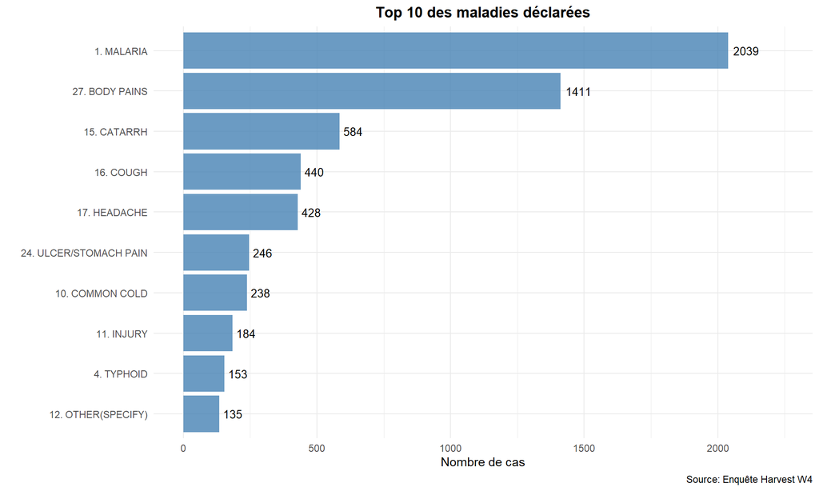

```r
ggplot(top_maladies,
       aes(x = n, y = reorder(type_maladie, n))) +
  geom_col(fill = "steelblue", alpha = 0.8) +
  geom_text(aes(label = n), hjust = -0.2, size = 3.5) +
  labs(
    x = "Nombre de cas",
    y = "",
    title = "Top 10 des maladies déclarées",
    caption = "Source: Enquête Harvest W4"
  ) +
  theme_minimal() +
  theme(plot.title = element_text(face = "bold", hjust = 0.5)) +
  xlim(0, max(top_maladies$n) * 1.1)
```

Analyse :

ggplot(top_maladies, aes(x = n, y = reorder(type_maladie, n))) : crée un graphique à barres horizontales avec le nombre de cas sur l’axe x et le type de maladie sur l’axe y, trié par fréquence.